# ESS 330 Final Project Report

Authors

Affiliation

Sarah Culhane

Colorado State University

Archer Goodman

Colorado State University

McKenna Cooper

Colorado State University

Published

May 14, 2025

```r
knitr::opts_chunk$set(
  echo = TRUE,
  message = FALSE,
  warning = FALSE,
  fig.path = "images/"
)
```

Source: Article Notebook

# Riparian Integrity and Aquatic Biodiversity: Linking Vegetation Condition, Water Quality, and Macroinvertebrate Richness in Lassen Volcanic National Park

### A Multivariate Analysis of Stream Ecosystem Health Across Varying Riparian Conditions

**Introduction**

Throughout the mythologies of ancient civilizations, rivers are often portrayed as sacred lifelines and mystical forces that breathe life into the land. From the Nile of Egypt to the Ganges in India, rivers shaped the very foundation of human development. The route a river carves through a landscape not only guides the path of its water, but also dictates the types of vegetation that grow alongside it, the diversity of animals that depend on it, and the feasibility of long-term human settlement. The majority of the world’s great cities were born beside rivers, not merely for commerce, which could be achieved from any coast, but for one elemental advantage: rivers carry fresh water. Drinkable water. Or at least, they used to.

In today’s world, the demand for freshwater is greater than ever. Global population growth, expanding agricultural demands, urban sprawl, and climate change are placing unprecedented stress on aquatic ecosystems. Historically, human progress has been closely tied to our ability to manipulate the quantity of water available through irrigation systems, dams, aqueducts, and other technologies (Yevjevich (1992)) But as environmental pressures grow, we are now forced to reckon with a second, equally critical dimension: water quality. Just as our ancestors learned to interpret the presence of certain plants and animals as signs of viable water sources, modern ecologists use biological indicators to evaluate the health of freshwater systems. Among the most widely used of these indicators are benthic macroinvertebrates; organisms that live on the bottom of rivers, lakes, and streams and include insects, crustaceans, mollusks, and worms. These organisms are uniquely valuable for biomonitoring due to their varied tolerance to pollutants, their limited mobility (which ties them to local conditions), and their life cycles, which span seasons or years (Gresens et al. (2009)). One particularly important group of macroinvertebrates used to indicate good water quality are those in the taxa Ephemeroptera (mayflies), Plecoptera (stoneflies), and Trichoptera (caddisflies). This group is often reffereed to as EPT in biomonitoring, and biological metrics based on EPT are often effective in detecting pollution due to their sensitivity to environmental disturbances (Barbour (1999)). Their presence in high abundance is often correlated with clean, well-oxygenated water. In contrast, a dominance of more pollution-tolerant organisms such as oligochaete worms, leeches, and midge larvae (Chironomidae) is typically a sign of poor water quality and habitat degradation (McDonald, Mullins, and Lewis (1991)).

Species richness, especially for benthic macroinvertebrates, is influenced by multiple complex factors when it comes to water quality. But some of the more influential factors seem to be PH, dissolved oxygen, and temperature (Burgmer, Hillebrand, and Pfenninger (2006), Courtney and Clements (1998)). Previous studies have shown that dissolved oxygen seems to be especially influential on taxonomic richness and diversity because of both the respiratory requirements of different taxa and their ability to handle low oxygen stress and the increased frequency of hypoxia in many aquatic systems due to anthropocentric activities (Connolly, Crossland, and Pearson (2004)).

But water quality is not influenced solely by what occurs within the streambed. The surrounding environment, particularly riparian zones, plays a critical role. Riparian zones are the transitional areas between terrestrial and aquatic ecosystems, typically encompassing the vegetation and soils adjacent to rivers and streams. Though narrow in spatial extent, riparian zones provide disproportionate ecological benefits. They act as natural buffers, filtering out sediments, nutrients, and pollutants before they reach the water body. They also stabilize stream banks, reduce erosion, moderate water temperature through shading, and provide crucial habitat for a wide range of terrestrial and aquatic organisms. As such, the integrity of riparian zones is often used as a secondary, yet equally important, indicator of watershed health (Sabo et al. (2005)). Unfortunately, riparian zones are frequently the first casualties of human development. Agricultural expansion, urbanization, logging, and road construction often involve the removal or fragmentation of riparian vegetation. When riparian zones are degraded, their ability to support both terrestrial and aquatic biodiversity diminishes, and the systems they protect become more vulnerable to pollution, sedimentation, and thermal stress. Consequently, monitoring the type and abundance of riparian vegetation can yield valuable insights into the overall ecological condition of a watershed, and by extension, its capacity to support a diverse and healthy macroinvertebrate community.

With these connections in mind, our project seeks to investigate the relationship between riparian zone condition, water quality, and freshwater invertebrate diversity. Specifically, we aim to evaluate whether the composition and abundance of riparian plant cover is associated with the composition and abundance of benthic macroinvertebrates, with an emphasis on EPT taxa as indicators of ecosystem health. By exploring these patterns, we hope to contribute to a better understanding of how human land use and vegetation management practices may impact water quality through both direct and indirect ecological pathways.

**Data Exploration**

All data for this project comes from the Klamath Lakes Monitoring Data Package 2013–2019, originally compiled by the U.S. Department of the Interior and now publicly available through Data.com. This dataset includes ecological monitoring records from Crater Lake National Park, Lassen Volcanic National Park, and Redwood National and State Park. However, for the purposes of our study, we will exclusively use data collected at Lassen Volcanic National Park, narrowing the geographic focus to improve consistency and data quality. The three files central to our analysis are InvertSpecies.csv, RiparianCover.csv, and WaterQuality.csv. These files contain complementary data and share key identifying columns, including Lake_Code, Start_Date, and Park_Name—which will allow us to merge the datasets and compare biological, physical, and vegetative conditions at each sampled water body.

**Methods**

Our analysis focused on assessing the relationship between riparian vegetation characteristics, water quality, and the diversity of freshwater macroinvertebrates, especially EPT taxa (Ephemeroptera, Plecoptera, Trichoptera), in Lassen Volcanic National Park for the years 2013 and 2019. We began by loading three datasets: InvertSpecies.csv, RiparianCover.csv, and WaterQuality.csv, filtering each to include only observations from Lassen Volcanic National Park in the target years. Using shared identifiers (Lake_Code, Start_Date, Park_Name), we merged the datasets for each year to create two comprehensive data frames, one for 2013 and one for 2019.

- Bar plots comparing insect order abundances by year
- Boxplots of water quality metrics across years
- A correlation heatmap to assess relationships between water quality parameters, EPT scores, and vegetation
- A vegetation cover comparison plot between 2013 and 2019

All analyses were conducted in RStudio using the tidymodels, tidyr, dplyr, and ggplot2, parsnip, vegan, and reshape2 packages.

**Results**

```r
# Load Libraries
library(ggplot2)
library(dplyr)
```

```r
library(tidymodels)
```

```r
library(parsnip)
library(vegan)
```

```r
library(tidyr)
library(reshape2)
```

```r
# Load data
invert_species <- read.csv("InvertSpecies (5).csv")
riparian_cover <- read.csv("RiparianCover (3).csv")
water_quality <- read.csv("WaterQuality (2).csv")

# Filter for Lassen Volcanic National Park and years 2013 and 2019
invert_filtered <- invert_species %>%
  filter(Park_Name == "Lassen Volcanic National Park" &
           (as.Date(Start_Date) >= as.Date("2013-01-01") & as.Date(Start_Date) <= as.Date("2013-12-31") |
            as.Date(Start_Date) >= as.Date("2019-01-01") & as.Date(Start_Date) <= as.Date("2019-12-31")))

riparian_filtered <- riparian_cover %>%
  filter(Park_Name == "Lassen Volcanic National Park" &
           (as.Date(Start_Date) >= as.Date("2013-01-01") & as.Date(Start_Date) <= as.Date("2013-12-31") |
            as.Date(Start_Date) >= as.Date("2019-01-01") & as.Date(Start_Date) <= as.Date("2019-12-31")))

water_quality_filtered <- water_quality %>%
  filter(Park_Name == "Lassen Volcanic National Park" &
           (as.Date(Start_Date) >= as.Date("2013-01-01") & as.Date(Start_Date) <= as.Date("2013-12-31") |
            as.Date(Start_Date) >= as.Date("2019-01-01") & as.Date(Start_Date) <= as.Date("2019-12-31")))

# Merge datasets
merged_data <- invert_filtered %>%
  inner_join(riparian_filtered, by = c("Lake_Code", "Park_Name", "Start_Date")) %>%
  inner_join(water_quality_filtered, by = c("Lake_Code", "Park_Name", "Start_Date"))
```

```r
# Add numeric riparian cover and convert Order
merged_data <- merged_data %>%
  mutate(
    Veg_Cover = case_when(
      Barren_AreaCcover == "sparse (<10%)" ~ 0.05,
      Barren_AreaCcover == "moderate (10-40%)" ~ 0.25,
      Barren_AreaCcover == "heavy (40-75%)" ~ 0.57,
      Barren_AreaCcover == "very heavy (>75%)" ~ 0.87),
    Order = as.factor(Order),
    Year = ifelse(as.Date(Start_Date) < as.Date("2014-01-01"), 2013, 2019)
  )

# Calculate Taxa Richness and Shannon Diversity
taxa_data <- merged_data %>%
  group_by(Start_Date, Lake_Code) %>%
  summarise(
    Taxa_Richness = n_distinct(Order),
    Shannon_Diversity = diversity(table(Order)),
    .groups = 'drop'
  )

# Join diversity metrics
merged_data <- merged_data %>%
  inner_join(taxa_data, by = c("Start_Date", "Lake_Code"))

# Split into 2013 and 2019 for visuals
melded_data_2013 <- merged_data %>% filter(Year == 2013)
melded_data_2019 <- merged_data %>% filter(Year == 2019)

# --- Modeling EPT Richness with environmental variables ---

set.seed(15379)
split_data <- initial_split(merged_data, prop = 0.8)
train_data <- training(split_data)
test_data <- testing(split_data)

recipe_model <- recipe(Taxa_Richness ~ Start_Date + Veg_Cover + Temperature_C + Dissolved_oxygen + pH + Depth_m + Turbidity, data = train_data) %>%
  step_normalize(all_numeric_predictors())

model_spec <- rand_forest(mtry = tune(), trees = 250, min_n = 500) %>%
  set_engine("ranger") %>%
  set_mode("regression")

workflow_model <- workflow() %>%
  add_model(model_spec) %>%
  add_recipe(recipe_model)

cv_folds <- vfold_cv(test_data, v = 5)

tune_results <- tune_grid(
  workflow_model,
  resamples = cv_folds,
  grid = 10
)
```

```r
best_model <- select_best(tune_results, metric = "rmse")
final_model <- finalize_model(model_spec, best_model)
final_workflow <- workflow_model %>% finalize_workflow(best_model)

fitted_model <- final_workflow %>% fit(data = train_data)

predictions <- predict(fitted_model, new_data = test_data) %>%
  bind_cols(test_data)

predictions %>%
  metrics(truth = Taxa_Richness, estimate = .pred)
```

```
# A tibble: 3 × 3
  .metric .estimator .estimate
  <chr>   <chr>          <dbl>
1 rmse    standard      0.133
2 rsq     standard      0.998
3 mae     standard      0.0296
```

The R squared Value for our model is 0.998. This is a fairly high value, which suggests that our model is a model of good fit for our observed data. The mean absolute error came out to be 0.0296. This is a fairly low number, which suggest that our model is fairly accurate.

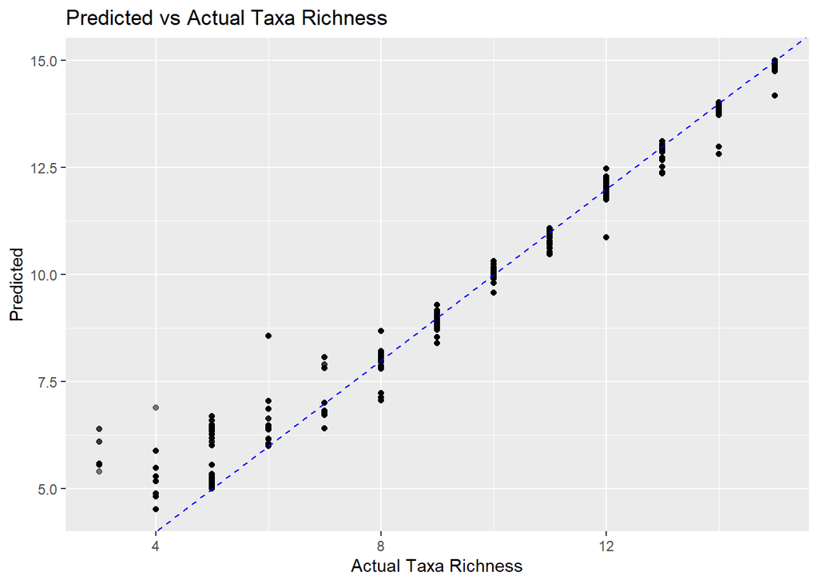

```r
# Predicted vs Actual Plot
predicted_vs_actual <- ggplot(predictions, aes(x = Taxa_Richness, y = .pred)) +
  geom_point(alpha = 0.5) +
  geom_abline(linetype = "dashed", color = "blue") +
  labs(x = "Actual Taxa Richness", y = "Predicted", title = "Predicted vs Actual Taxa Richness")

print(predicted_vs_actual)
```

The predicted vs actual plot showing taxonomic richness does show some slight variance, but the overall fit is fairly linear, providing sufficient evidence that the model chosen is a model of good fit

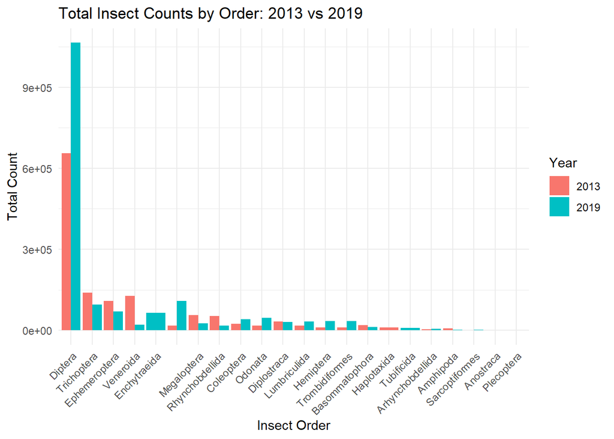

```r
# Insect Order Abundance
order_counts <- merged_data %>%
  group_by(Year, Order) %>%
  summarise(Total_Count = sum(Count, na.rm = TRUE), .groups = "drop")

insect_order_abundane <- ggplot(order_counts, aes(x = reorder(Order, -Total_Count), y = Total_Count, fill = factor(Year))) +
  geom_col(position = "dodge") +
  labs(title = "Total Insect Counts by Order: 2013 vs 2019", x = "Insect Order", y = "Total Count", fill = "Year") +
  theme_minimal() +
  theme(axis.text.x = element_text(angle = 45, hjust = 1))

print(insect_order_abundane)
```

According to to the graph above showing total insect count by order in 2013 to 2019, the abundance of insects in the order diptera was the highest in both years, and there was an increase between 2013 and 2019. The abundance of insects in the order Trichoptera, Ephemeroptera, and veneroida, however, decreased from 2013 to 2019.

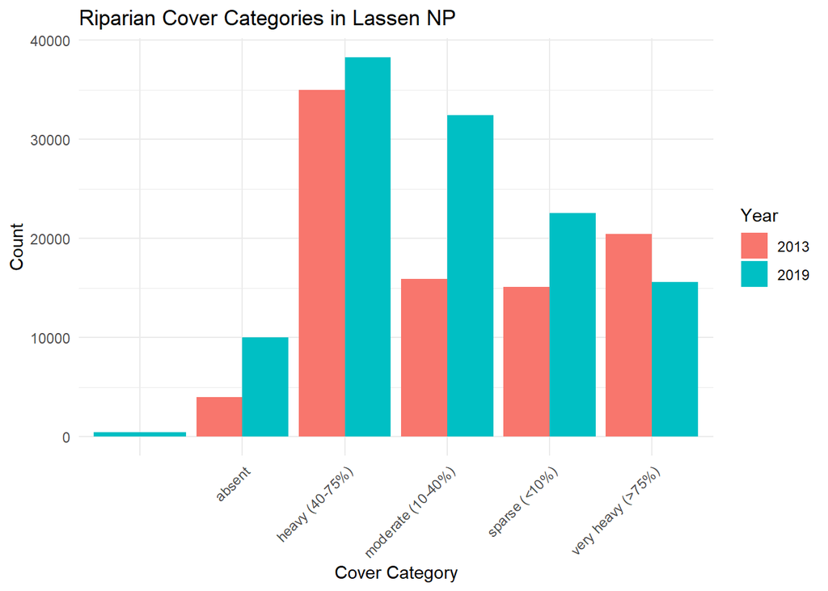

```r
# Riparian Cover Categories
riparian_combined <- merged_data %>%
  select(Barren_AreaCcover, Year)

riparian_cover <- ggplot(riparian_combined, aes(x = Barren_AreaCcover, fill = factor(Year))) +
  geom_bar(position = "dodge") +
  labs(title = "Riparian Cover Categories in Lassen NP", x = "Cover Category", y = "Count", fill = "Year") +
  theme_minimal() +
  theme(axis.text.x = element_text(angle = 45, hjust = 1))

print(riparian_cover)
```

According to the graph above, the amount of riparian cover in every category except very heavy (>75%) increased from 2013 to 2019.

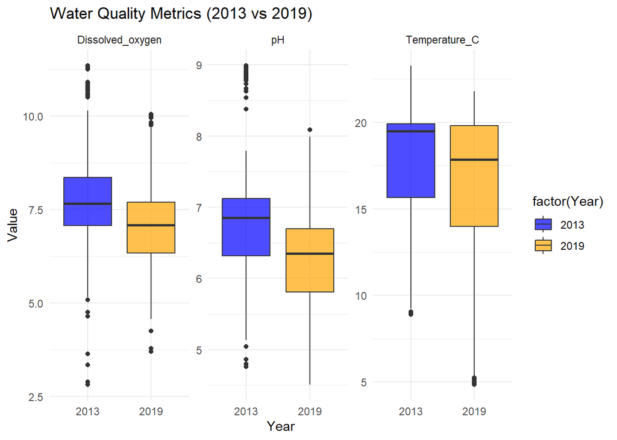

```r
# Water Quality Box Plots
water_quality_long <- merged_data %>%
  select(Temperature_C, Dissolved_oxygen, pH, Year) %>%
  drop_na() %>%
  pivot_longer(cols = c(Temperature_C, Dissolved_oxygen, pH), names_to = "Metric", values_to = "Value")

water_quality <- ggplot(water_quality_long, aes(x = factor(Year), y = Value, fill = factor(Year))) +
  geom_boxplot(alpha = 0.7) +
  facet_wrap(~ Metric, scales = "free_y") +
  labs(title = "Water Quality Metrics (2013 vs 2019)", x = "Year", y = "Value") +
  scale_fill_manual(values = c("2013" = "blue", "2019" = "orange")) +
  theme_minimal()

print(water_quality)
```

According to the boxplot above, the mean amount of dissolved oxygen, mean pH, and mean temperature all decreased from 2013 to 2019. This reflects an overall decline in water quality in lakes and ponds within Lassen Volcanic National Park.

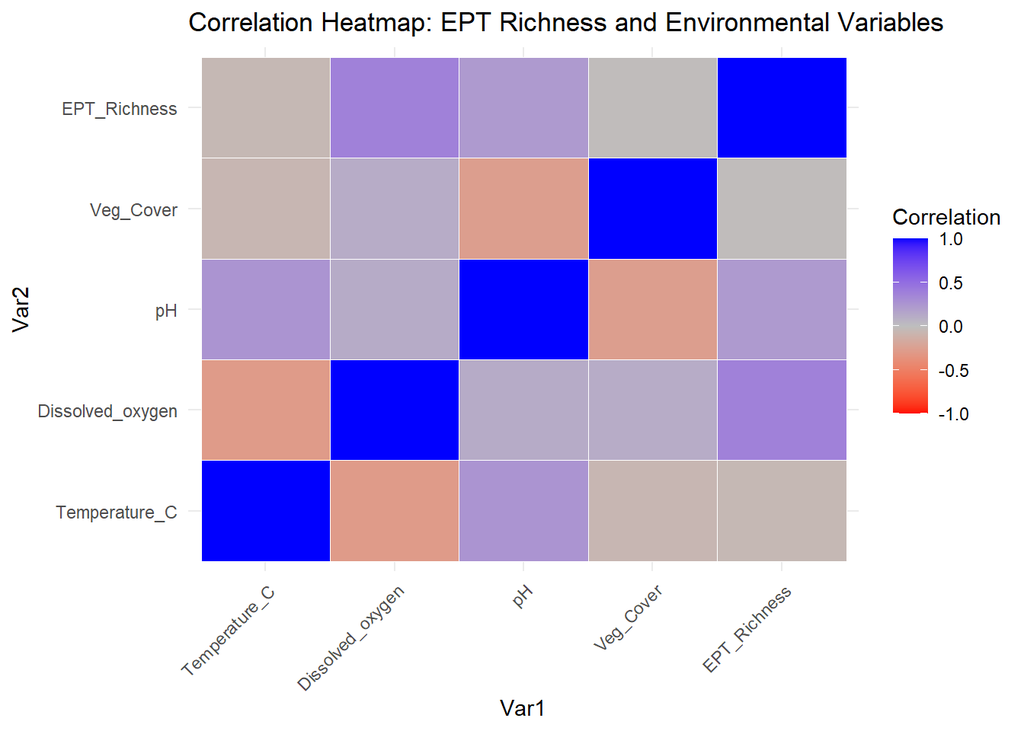

```r
# Correlation Heatmap
ept_richness <- merged_data %>%
  filter(Order %in% c("Ephemeroptera", "Plecoptera", "Trichoptera")) %>%
  group_by(Start_Date, Lake_Code) %>%
  summarise(EPT_Richness = n_distinct(Order), .groups = "drop")

correlation_data <- merged_data %>%
  group_by(Start_Date, Lake_Code) %>%
  slice(1) %>%
  ungroup() %>%
  left_join(ept_richness, by = c("Start_Date", "Lake_Code")) %>%
  select(Temperature_C, Dissolved_oxygen, pH, Veg_Cover, EPT_Richness) %>%
  drop_na()

cor_matrix <- cor(correlation_data, use = "complete.obs")
cor_melt <- melt(cor_matrix)

correlation_heatmap <- ggplot(cor_melt, aes(Var1, Var2, fill = value)) +
  geom_tile(color = "white") +
  scale_fill_gradient2(low = "red", high = "blue", mid = "grey",
                       midpoint = 0, limit = c(-1, 1), name = "Correlation") +
  labs(title = "Correlation Heatmap: EPT Richness and Environmental Variables") +
  theme_minimal() +
  theme(axis.text.x = element_text(angle = 45, hjust = 1))

print(correlation_heatmap)
```

**Discussion**

Although vegetation is often considered a useful indicator of ecosystem health, its relationship with water quality and biological condition is influenced by many interacting processes. As Dosskey et al. (2010) suggests, understanding these underlying mechanisms is essential to accurately use vegetation condition as an indicator and to realistically assess how effective vegetation restoration might be in improving water quality. This is further supported by evidence from Lassen’s Butte and Manzanita Lakes, which have shown differential responses to nutrient-climate pressures due to unique local controls like hydro-geologic settings and trophic interactions (Howard (2018)). Going forward, more focused research and data collection needs to be done to find the source of pollution in Lassen Volcanic National Park so that measures can be taken to combat pollution at the source and improve the water quality of water bodies within the park. Limitations of our analysis include the fact that there was a lot of cleaning that had to be done in our dataset, and there was a disproportionate amount of data for each of the national parks and years that data was collected, with some parks and years having significantly more data than others. Crater Lake National Park especially had less data than both Volcanic National Park and Redwood National State Park.

## References

Barbour, Michael T. 1999. *Rapid Bioassessment Protocols for Use in Wadeable Streams and Rivers: Periphyton, Benthic Macroinvertebrates and Fish*. US Environmental Protection Agency, Office of Water.

Burgmer, T., H. Hillebrand, and M. Pfenninger. 2006. “Effects of Climate-Driven Temperature Changes on the Diversity of Freshwater Macroinvertebrates.” *Oecologia* 151 (1): 93–103. https://doi.org/10.1007/s00442-006-0542-9.

Connolly, Niall, Michael Crossland, and R. Pearson. 2004. “Effect of Low Dissolved Oxygen on Survival, Emergence, and Drift of Tropical Stream Macroinvertebrates.” *Journal of The North American Benthological Society - J N AMER BENTHOL SOC* 23 (June): 251–70. https://doi.org/10.1899/0887-3593(2004)023<0251:EOLDOO>2.0.CO;2.

Courtney, Lori A., and William H. Clements. 1998. “Effects of Acidic pH on Benthic Macroinvertebrate Communities in Stream Microcosms.” *Hydrobiologia* 379 (1–3): 135–45. https://doi.org/10.1023/a:1003442013650.

Dosskey, Michael G, Philippe Vidon, Noel P Gurwick, Craig J Allan, Tim P Duval, and Richard Lowrance. 2010. “The Role of Riparian Vegetation in Protecting and Improving Chemical Water Quality in Streams 1.” *JAWRA Journal of the American Water Resources Association* 46 (2): 261–77.

Gresens, Susan, Robert Smith, Ariana Sutton-Grier, and Melissa Kenney. 2009. “Benthic Macroinvertebrates as Indicators of Water Quality: The Intersection of Science and Policy.” *Terrestrial Arthropod Reviews* 2 (2): 99–128. https://doi.org/10.1163/187498209x12525675906077.

Howard, Kerry Louise. 2018. “Neo and Paleo-Limnological Response to Nutrient, Climate, and Volcanic Stressors over the Past 100 Years at Butte, Manzanita, and Widow Lakes in Lassen Volcanic National Park (CA, USA).” PhD thesis, University of Nevada, Reno.

McDonald, Brook S., Gary W. Mullins, and Stuart Lewis. 1991. “Macroinvertebrates as Indicators of Stream Health.” *The American Biology Teacher* 53 (8): 462–66. https://doi.org/10.2307/4449370.

Sabo, John L., Ryan Sponseller, Mark Dixon, Kris Gade, Tamara Harms, Jim Heffernan, Andrea Jani, et al. 2005. “RIPARIAN ZONES INCREASE REGIONAL SPECIES RICHNESS BY HARBORING DIFFERENT, NOT MORE, SPECIES.” *Ecology* 86 (1): 56–62. https://doi.org/https://doi.org/10.1890/04-0668.

Yevjevich, Vujica. 1992. “Water and Civilization.” *Water International* 17 (4): 163–71. https://doi.org/10.1080/02508069208686135.